# Notes - Class 1

Simon G. Brauer

Tuesday, October 06, 2015

# Class 1: October 6th, 2015

## Websites for the class

http://socviz.github.io/soc880/

http://github.com/socviz/soc880

## First sample code (sort of)

```r
data <- c(1, 1, 4, 1, 1, 4, 1)
data
```

```
## [1] 1 1 4 1 1 4 1
```

```r
x <- rnorm(n = 100)
y <- x + rnorm(n = 100)
```

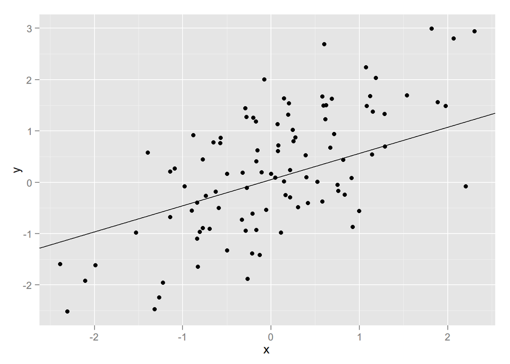

## Details on R

R has a working directory

```r
getwd()
```

```
## [1] "C:/Users/Simon/OneDrive/Documents/Github/Data-Visualization"
```

How Kieran organizes his working directory…

1. data folder
2. doc folder
3. figures folder
- r file in root

everything in R is an object…

```r
(my_numbers <- c(1, 2, 3, 1, 3,5, 25))
```

```
## [1]  1  2  3  1  3  5 25
```

```r
summary(my_numbers)
```

```
##    Min. 1st Qu.  Median    Mean 3rd Qu.    Max.
##   1.000   1.500   3.000   5.714   4.000  25.000
```

every object has a class

```r
class(my_numbers)
```

```
## [1] "numeric"
```

```r
#even functions have classes
class(summary)
```

```
## [1] "function"
```

Objects can hold the output of functions

```r
(my_summary <- summary(my_numbers))
```

```
##    Min. 1st Qu.  Median    Mean 3rd Qu.    Max.
##   1.000   1.500   3.000   5.714   4.000  25.000
```

```r
class(my_summary)
```

```
## [1] "summaryDefault" "table"
```

Examples in R

```r
my_numbers * 2
```

```
## [1]  2  4  6  2  6 10 50
```

```r
table(my_numbers)
```

```
## my_numbers
##  1  2  3  5 25
##  2  1  2  1  1
```

```r
sd(my_numbers)
```

```
## [1] 8.616153
```

you can get information in different ways

```r
str(my_numbers)
```

```
##  num [1:7] 1 2 3 1 3 5 25
```

```r
str(my_summary)
```

```
## Classes 'summaryDefault', 'table'  Named num [1:6] 1 1.5 3 5.71 4 ...
##   ..- attr(*, "names")= chr [1:6] "Min." "1st Qu." "Median" "Mean" ...
```

```r
str(summary)
```

```
## function (object, ...)
```

# why are charts sometimes bad?

*Pure aesthetics: presentation is fine but ugly

*Figure shows you less than it should or could

*Figure shows more than it should

*Figure can be misleading or misrepresent the data, accidentally or purposefully

Consider the actual amount of information you’re presenting and conside simplifying to emphasizeit (instead the background, coloring, etc.)

*Look at William Cleveland’s work on presenting data*

His thoughts:

- It’s difficult to compare without common baselines
- People misjudge areas like crazy
- Acute angles are underestimated, obtuse are overestimated
- You can’t distinguish data points if they are overlapping
- Colors are good for distinguishing categories but not for continuous variables
- Difficult at interpreting curves because our perception is influenced by horizontal space

### Let’s get some data…

```r
library(devtools)
```

```r
gapminder.url <- "https://raw.githubusercontent.com/socviz/soc880/master/data/gapminder.csv"

## What type of object is this?
class(gapminder.url)
```

```
## [1] "character"
```

```r
data <- read.csv(url(gapminder.url))
class(data)
```

```
## [1] "data.frame"
```

```r
str(data)
```

```
## 'data.frame':    1704 obs. of  6 variables:
##  $ country  : Factor w/ 142 levels "Afghanistan",..: 3 3 3 3 3 3 3 3 3 3 ...
##  $ continent: Factor w/ 5 levels "Africa","Americas",..: 1 1 1 1 1 1 1 1 1 1 ...
##  $ year     : int  1952 1957 1962 1967 1972 1977 1982 1987 1992 1997 ...
##  $ lifeExp  : num  43.1 45.7 48.3 51.4 54.5 ...
##  $ pop      : num  9279525 10270856 11000948 12760499 14760787 ...
##  $ gdpPercap: num  2449 3014 2551 3247 4183 ...
```

```r
head(data)
```

```
##   country continent year lifeExp      pop gdpPercap
## 1 Algeria    Africa 1952  43.077  9279525  2449.008
## 2 Algeria    Africa 1957  45.685 10270856  3013.976
## 3 Algeria    Africa 1962  48.303 11000948  2550.817
## 4 Algeria    Africa 1967  51.407 12760499  3246.992
## 5 Algeria    Africa 1972  54.518 14760787  4182.664
## 6 Algeria    Africa 1977  58.014 17152804  4910.417
```

let’s plot it!

```r
p <- ggplot(data = data, aes(x = gdpPercap, y = lifeExp))
lm(data = data, formula = lifeExp ~ gdpPercap)
```

```
##
## Call:
## lm(formula = lifeExp ~ gdpPercap, data = data)
##
## Coefficients:
## (Intercept)    gdpPercap
##   5.396e+01    7.649e-04
```

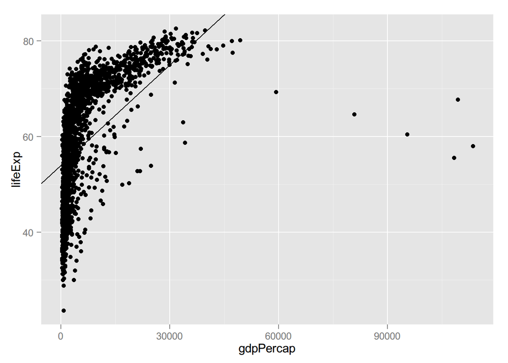

```r
p + geom_point() + geom_abline(intercept = 54, slope = 0.0007)
```

## Homework for next time

1. Create an RMarkdown file for your work
2. Look again at the data
3. Put lifeExp on the x-axis and gdpPercap on the y-axis
4. plot pop on the x-axis and gdpPercap on the y-axis
5. Plot year on the x-axis and any continuous variable on the y-axis

# Homework

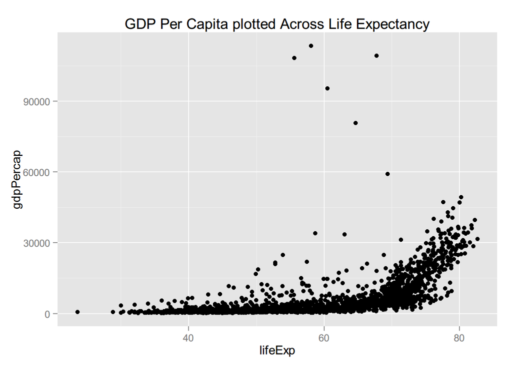

```r
##Put lifeEXP on the x-axis and gdpPercap on the y-axis
ggplot(data = data, aes(x = lifeExp, y = gdpPercap)) + geom_point() + labs(title = "GDP Per Capita plotted Across Life Expectancy")
```

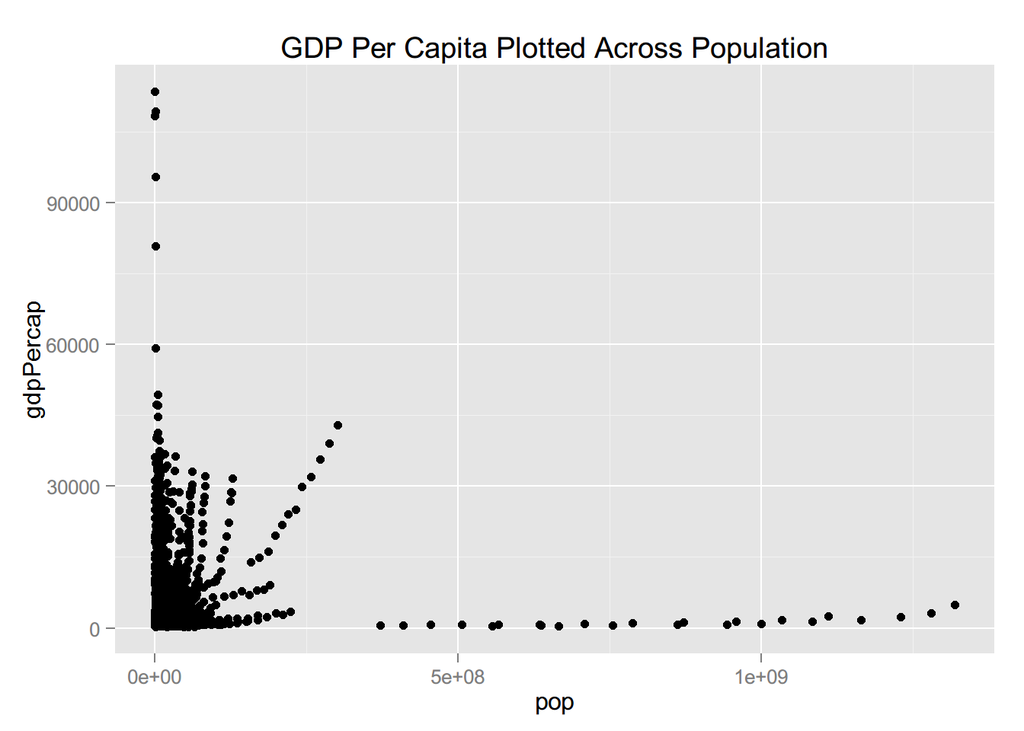

```r
##Put pop on the x-axis and gdpPercap on the y-axis
ggplot(data = data, aes(x = pop, y = gdpPercap)) + geom_point() + labs(title = "GDP Per Capita Plotted Across Population")
```

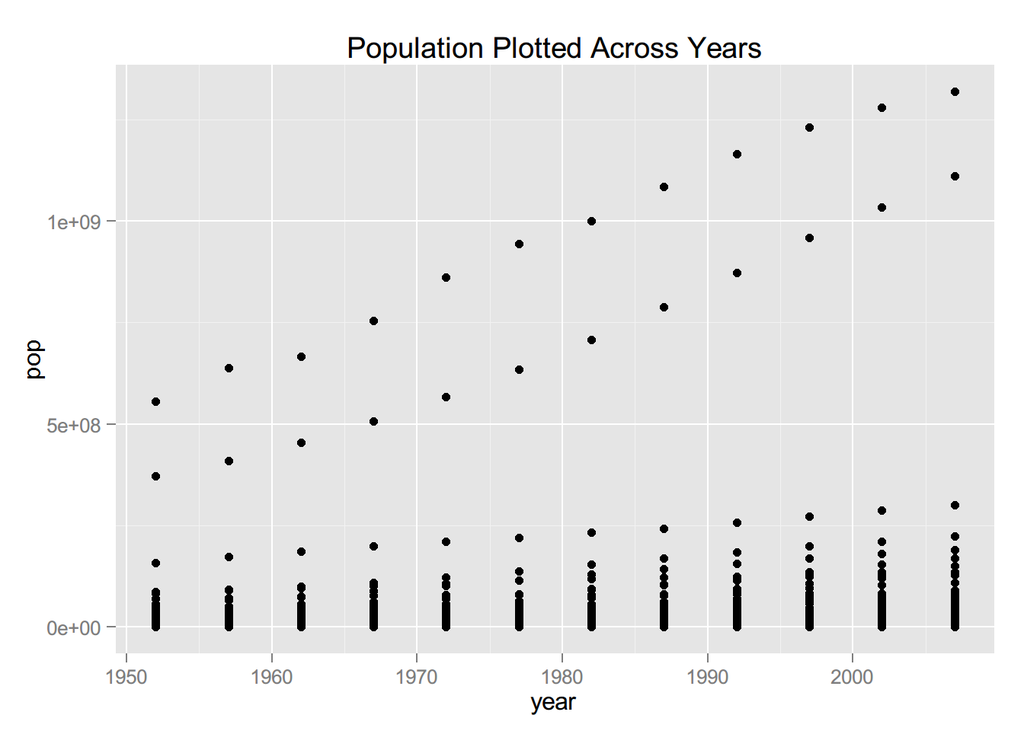

```r
##Plot year on the x-axis and any continuous variable on the y-axis
ggplot(data = data, aes(x = year, y = pop)) + geom_point() + labs(title = "Population Plotted Across Years")
```